# 极客时间 | 现代C++实战30讲

[figure not shown]

# 02 | 自己动手，实现C++的智能指针

2019-11-25 吴咏炜

现代C++实战30讲

[figure not shown]

### 讲述：吴咏炜

[interactive chart not shown]

你好，我是吴咏炜。

上一讲，我们描述了一个某种程度上可以当成智能指针用的类 shape_wrapper。使用那个智能指针，可以简化资源的管理，从根本上消除资源（包括内存）泄漏的可能性。这一讲我们就来进一步讲解，如何将 shape_wrapper 改造成一个完整的智能指针。你会看到，智能指针本质上并不神秘，其实就是 RAII 资源管理功能的自然展现而已。

在学完这一讲之后，你应该会对 C++ 的 unique_ptr 和 shared_ptr 的功能非常熟悉了。同时，如果你今后要创建类似的资源管理类，也不会是一件难事。

## 回顾

我们上一讲给出了下面这个类：

class shape_wrapper {

public:

explicit shape_wrapper(

shape* ptr = nullptr)

: ptr_(ptr) {}

~shape_wrapper()

{

delete ptr_;

}

shape* get() const { return ptr_; }

private:

shape* ptr_;

};

这个类可以完成智能指针的最基本的功能：对超出作用域的对象进行释放。但它缺了点东西：

这个类只适用于 shape 类

该类对象的行为不够像指针

拷贝该类对象会引发程序行为异常

下面我们来逐一看一下怎么弥补这些问题。

## 模板化和易用性

要让这个类能够包装任意类型的指针，我们需要把它变成一个类模板。这实际上相当容易：

template <typename T>

class smart_ptr {

public:

explicit smart_ptr(T* ptr = nullptr)

: ptr_(ptr) {}

~smart_ptr()

{

delete ptr_;

}

T* get() const { return ptr_; }

private:

T* ptr_;

};

和 shape_wrapper 比较一下，我们就是在开头增加模板声明 template <typename T>，然后把代码中的 shape 替换成模板参数 T 而已。这些修改非常简单自然吧？模板本质上并不是一个很复杂的概念。这个模板使用也很简单，把原来的 shape_wrapper 改成 smart_ptr<shape> 就行。

目前这个 smart_ptr 的行为还是和指针有点差异的：

它不能用 * 运算符解引用

它不能用 -> 运算符指向对象成员

它不能像指针一样用在布尔表达式里

不过，这些问题也相当容易解决，加几个成员函数就可以：

template <typename T>

class smart_ptr {

public:

…

T& operator*() const { return *ptr_; }

T* operator->() const { return ptr_; }

operator bool() const { return ptr_; }

}

## 拷贝构造和赋值

拷贝构造和赋值，我们暂且简称为拷贝，这是个比较复杂的问题了。关键还不是实现问题，而是我们该如何定义其行为。假设有下面的代码：

smart_ptr<shape> ptr1{create_shape(shape_type::circle)};

smart_ptr<shape> ptr2{ptr1};

对于第二行，究竟应当让编译时发生错误，还是可以有一个更合理的行为？我们来逐一检查一下各种可能性。

最简单的情况显然是禁止拷贝。我们可以使用下面的代码：

template <typename T>

class smart_ptr {

…

smart_ptr(const smart_ptr&)

= delete;

smart_ptr& operator=(const smart_ptr&)

= delete;

…

};

禁用这两个函数非常简单，但却解决了一种可能出错的情况。否则，smart_ptr<shape> ptr2{ptr1}; 在编译时不会出错，但在运行时却会有未定义行为——由于会对同一内存释放两次，通常情况下会导致程序崩溃。

我们是不是可以考虑在拷贝智能指针时把对象拷贝一份？不行，通常人们不会这么用，因为使用智能指针的目的就是要减少对象的拷贝啊。何况，虽然我们的指针类型是 shape，但实际指向的却应该是 circle 或 triangle 之类的对象。在 C++ 里没有像 Java 的 clone 方法这样的约定；一般而言，并没有通用的方法可以通过基类的指针来构造出一个子类的对象来。

我们要么试试在拷贝时转移指针的所有权？大致实现如下：

template <typename T>

class smart_ptr {

…

smart_ptr(smart_ptr& other)

{

ptr_ = other.release();

}

smart_ptr& operator=(smart_ptr& rhs)

{

smart_ptr(rhs).swap(*this);

return *this;

}

…

T* release()

{

T* ptr = ptr_;

ptr_ = nullptr;

return ptr;

}

void swap(smart_ptr& rhs)

{

using std::swap;

swap(ptr_, rhs.ptr_);

}

…

};

在拷贝构造函数中，通过调用 other 的 release 方法来释放它对指针的所有权。在赋值函数中，则通过拷贝构造产生一个临时对象并调用 swap 来交换对指针的所有权。实现上是不复杂的。

如果你学到的赋值函数还有一个类似于 if (this != &rhs) 的判断的话，那种用法更啰嗦，而且异常安全性不够好——如果在赋值过程中发生异常的话，this 对象的内容可能已经被部分破坏了，对象不再处于一个完整的状态。

目前这种惯用法（见参考资料 [1]）则保证了强异常安全性：赋值分为拷贝构造和交换两步，异常只可能在第一步发生；而第一步如果发生异常的话，this 对象完全不受任何影响。无论拷贝构造成功与否，结果只有赋值成功和赋值没有效果两种状态，而不会发生因为赋值破坏了当前对象这种场景。

如果你觉得这个实现还不错的话，那恭喜你，你达到了 C++ 委员会在 1998 年时的水平：上面给出的语义本质上就是 C++98 的 auto_ptr 的定义。如果你觉得这个实现很别扭的话，也恭喜你，因为 C++ 委员会也是这么觉得的：auto_ptr 在 C++17 时已经被正式从 C++ 标准里删除了。

上面实现的最大问题是，它的行为会让程序员非常容易犯错。一不小心把它传递给另外一个 smart_ptr，你就不再拥有这个对象了……

## “移动”指针？

在下一讲我们将完整介绍一下移动语义。这一讲，我们先简单看一下 smart_ptr 可以如何使用“移动”来改善其行为。

我们需要对代码做两处小修改：

template <typename T>

class smart_ptr {

…

smart_ptr(smart_ptr&& other)

{

ptr_ = other.release();

}

smart_ptr& operator=(smart_ptr rhs)

{

rhs.swap(*this);

return *this;

}

…

};

看到修改的地方了吗？我改了两个地方：

把拷贝构造函数中的参数类型 smart_ptr& 改成了 smart_ptr&&；现在它成了移动构造函数。

把赋值函数中的参数类型 smart_ptr& 改成了 smart_ptr，在构造参数时直接生成新的智能指针，从而不再需要在函数体中构造临时对象。现在赋值函数的行为是移动还是拷贝，完全依赖于构造参数时走的是移动构造还是拷贝构造。

根据 C++ 的规则，如果我提供了移动构造函数而没有手动提供拷贝构造函数，那后者自动被禁用（记住，C++ 里那些复杂的规则也是为方便编程而设立的）。于是，我们自然地得到了以下结果：

smart_ptr<shape> ptr1{create_shape(shape_type::circle)};

smart_ptr<shape> ptr2{ptr1}; // 编译出错

smart_ptr<shape> ptr3;

ptr3 = ptr1; // 编译出错

ptr3 = std::move(ptr1); // OK，可以

smart_ptr<shape> ptr4{std::move(ptr3)}; // OK，可以

这个就自然多了。

这也是 C++11 的 unique_ptr 的基本行为。

## 子类指针向基类指针的转换

哦，我撒了一个小谎。不知道你注意到没有，一个 circle* 是可以隐式转换成 shape* 的，但上面的 smart_ptr<circle> 却无法自动转换成 smart_ptr<shape>。这个行为显然还是不够“自然”。

不过，只需要额外加一点模板代码，就能实现这一行为。在我们目前给出的实现里，只需要修改我们的移动构造函数一处即可——这也算是我们让赋值函数使用拷贝 / 移动构造函数的好处了。

template <typename U>

smart_ptr(smart_ptr<U>&& other)

{

ptr_ = other.release();

}

这样，我们自然而然利用了指针的转换特性：现在 smart_ptr<circle> 可以移动给 smart_ptr<shape>，但不能移动给 smart_ptr<triangle>。不正确的转换会在代码编译时直接报错。

至于非隐式的转换，因为本来就是要写特殊的转换函数的，我们留到这一讲的最后再讨论。

## 引用计数

unique_ptr 算是一种较为安全的智能指针了。但是，一个对象只能被单个 unique_ptr 所拥有，这显然不能满足所有使用场合的需求。一种常见的情况是，多个智能指针同时拥有一个对象；当它们全部都失效时，这个对象也同时会被删除。这也就是 shared_ptr 了。

unique_ptr 和 shared_ptr 的主要区别如下图所示：

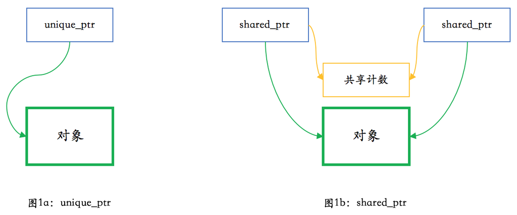

多个不同的 shared_ptr 不仅可以共享一个对象，在共享同一对象时也需要同时共享同一个计数。当最后一个指向对象（和共享计数）的 shared_ptr 析构时，它需要删除对象和共享计数。我们下面就来实现一下。

我们先来写出共享计数的接口：

class shared_count {

public:

shared_count();

void add_count();

long reduce_count();

long get_count() const;

};

这个 shared_count 类除构造函数之外有三个方法：一个增加计数，一个减少计数，一个获取计数。注意上面的接口增加计数不需要返回计数值；但减少计数时需要返回计数值，以供调用者判断是否它已经是最后一个指向共享计数的 shared_ptr 了。由于真正多线程安全的版本需要用到我们目前还没学到的知识，我们目前先实现一个简单化的版本：

class shared_count {

public:

shared_count() : count_(1) {}

void add_count()

{

++count_;

}

long reduce_count()

{

return --count_;

}

long get_count() const

{

return count_;

}

private:

long count_;

};

现在我们可以实现我们的引用计数智能指针了。首先是构造函数、析构函数和私有成员变量：

template <typename T>

class smart_ptr {

public:

explicit smart_ptr(T* ptr = nullptr)

: ptr_(ptr)

{

if (ptr) {

shared_count_ =

new shared_count();

}

}

~smart_ptr()

{

if (ptr_ &&

!shared_count_

->reduce_count()) {

delete ptr_;

delete shared_count_;

}

}

private:

T* ptr_;

shared_count* shared_count_;

};

构造函数跟之前的主要不同点是会构造一个 shared_count 出来。析构函数在看到 ptr_ 非空时（此时根据代码逻辑，shared_count 也必然非空），需要对引用数减一，并在引用数降到零时彻底删除对象和共享计数。原理就是这样，不复杂。

当然，我们还有些细节要处理。为了方便实现赋值（及其他一些惯用法），我们需要一个新的 swap 成员函数：

void swap(smart_ptr& rhs)

{

using std::swap;

swap(ptr_, rhs.ptr_);

swap(shared_count_,

rhs.shared_count_);

}

赋值函数可以跟前面一样，保持不变，但拷贝构造和移动构造函数是需要更新一下的：

template <typename U>

smart_ptr(const smart_ptr<U>& other)

{

ptr_ = other.ptr_;

if (ptr_) {

other.shared_count_

->add_count();

shared_count_ =

other.shared_count_;

}

}

template <typename U>

smart_ptr(smart_ptr<U>&& other)

{

ptr_ = other.ptr_;

if (ptr_) {

shared_count_ =

other.shared_count_;

other.ptr_ = nullptr;

}

}

除复制指针之外，对于拷贝构造的情况，我们需要在指针非空时把引用数加一，并复制共享计数的指针。对于移动构造的情况，我们不需要调整引用数，直接把 other.ptr_ 置为空，认为 other 不再指向该共享对象即可。

不过，上面的代码有个问题：它不能正确编译。编译器会报错，像：

fatal error: ‘ptr_’ is a private member of ‘smart_ptr<circle>’

错误原因是模板的各个实例间并不天然就有 friend 关系，因而不能互访私有成员 ptr_ 和 shared_count_。我们需要在 smart_ptr 的定义中显式声明：

template <typename U>

friend class smart_ptr;

此外，我们之前的实现（类似于单一所有权的 unique_ptr ）中用 release 来手工释放所有权。在目前的引用计数实现中，它就不太合适了，应当删除。但我们要加一个对调试非常有用的函数，返回引用计数值。定义如下：

long use_count() const

{

if (ptr_) {

return shared_count_

->get_count();

} else {

return 0;

}

}

这就差不多是一个比较完整的引用计数智能指针的实现了。我们可以用下面的代码来验证一下它的功能正常：

class shape {

public:

virtual ~shape() {}

};

class circle : public shape {

public:

~circle() { puts("~circle()"); }

};

int main()

{

smart_ptr<circle> ptr1(new circle());

printf("use count of ptr1 is %ld\n",

ptr1.use_count());

smart_ptr<shape> ptr2;

printf("use count of ptr2 was %ld\n",

ptr2.use_count());

ptr2 = ptr1;

printf("use count of ptr2 is now %ld\n",

ptr2.use_count());

if (ptr1) {

puts("ptr1 is not empty");

}

}

这段代码的运行结果是：

use count of ptr1 is 1

use count of ptr2 was 0

use count of ptr2 is now 2

ptr1 is not empty

~circle()

上面我们可以看到引用计数的变化，以及最后对象被成功删除。

## 指针类型转换

对应于 C++ 里的不同的类型强制转换：

static_cast

reinterpret_cast

const_cast

dynamic_cast

智能指针需要实现类似的函数模板。实现本身并不复杂，但为了实现这些转换，我们需要添加构造函数，允许在对智能指针内部的指针对象赋值时，使用一个现有的智能指针的共享计数。如下所示：

template <typename U>

smart_ptr(const smart_ptr<U>& other,

T* ptr)

{

ptr_ = ptr;

if (ptr_) {

other.shared_count_

->add_count();

shared_count_ =

other.shared_count_;

}

}

这样我们就可以实现转换所需的函数模板了。下面实现一个 dynamic_pointer_cast 来示例一下：

template <typename T, typename U>

smart_ptr<T> dynamic_pointer_cast(

const smart_ptr<U>& other)

{

T* ptr =

dynamic_cast<T*>(other.get());

return smart_ptr<T>(other, ptr);

}

在前面的验证代码后面我们可以加上：

smart_ptr<circle> ptr3 =

dynamic_pointer_cast<circle>(ptr2);

printf("use count of ptr3 is %ld\n",

ptr3.use_count());

编译会正常通过，同时能在输出里看到下面的结果：

use count of ptr3 is 3

最后，对象仍然能够被正确删除。这说明我们的实现是正确的。

## 代码列表

为了方便你参考，下面我给出了一个完整的 smart_ptr 代码列表：

#include <utility> // std::swap

class shared_count {

public:

shared_count() noexcept

: count_(1) {}

void add_count() noexcept

{

++count_;

}

long reduce_count() noexcept

{

return --count_;

}

long get_count() const noexcept

{

return count_;

}

private:

long count_;

};

template <typename T>

class smart_ptr {

public:

template <typename U>

friend class smart_ptr;

explicit smart_ptr(T* ptr = nullptr)

: ptr_(ptr)

{

if (ptr) {

shared_count_ =

new shared_count();

}

}

~smart_ptr()

{

printf("~smart_ptr(): %p\n", this);

if (ptr_ &&

!shared_count_

->reduce_count()) {

delete ptr_;

delete shared_count_;

}

}

template <typename U>

smart_ptr(const smart_ptr<U>& other) noexcept

{

ptr_ = other.ptr_;

if (ptr_) {

other.shared_count_->add_count();

shared_count_ = other.shared_count_;

}

}

template <typename U>

smart_ptr(smart_ptr<U>&& other) noexcept

{

ptr_ = other.ptr_;

if (ptr_) {

shared_count_ =

other.shared_count_;

other.ptr_ = nullptr;

}

}

template <typename U>

smart_ptr(const smart_ptr<U>& other,

T* ptr) noexcept

{

ptr_ = ptr;

if (ptr_) {

other.shared_count_

->add_count();

shared_count_ =

other.shared_count_;

}

}

smart_ptr&

operator=(smart_ptr rhs) noexcept

{

rhs.swap(*this);

return *this;

}

T* get() const noexcept

{

return ptr_;

}

long use_count() const noexcept

{

if (ptr_) {

return shared_count_

->get_count();

} else {

return 0;

}

}

void swap(smart_ptr& rhs) noexcept

{

using std::swap;

swap(ptr_, rhs.ptr_);

swap(shared_count_,

rhs.shared_count_);

}

T& operator*() const noexcept

{

return *ptr_;

}

T* operator->() const noexcept

{

return ptr_;

}

operator bool() const noexcept

{

return ptr_;

}

private:

T* ptr_;

shared_count* shared_count_;

};

template <typename T>

void swap(smart_ptr<T>& lhs,

smart_ptr<T>& rhs) noexcept

{

lhs.swap(rhs);

}

template <typename T, typename U>

smart_ptr<T> static_pointer_cast(

const smart_ptr<U>& other) noexcept

{

T* ptr = static_cast<T*>(other.get());

return smart_ptr<T>(other, ptr);

}

template <typename T, typename U>

smart_ptr<T> reinterpret_pointer_cast(

const smart_ptr<U>& other) noexcept

{

T* ptr = reinterpret_cast<T*>(other.get());

return smart_ptr<T>(other, ptr);

}

template <typename T, typename U>

smart_ptr<T> const_pointer_cast(

const smart_ptr<U>& other) noexcept

{

T* ptr = const_cast<T*>(other.get());

return smart_ptr<T>(other, ptr);

}

template <typename T, typename U>

smart_ptr<T> dynamic_pointer_cast(

const smart_ptr<U>& other) noexcept

{

T* ptr = dynamic_cast<T*>(other.get());

return smart_ptr<T>(other, ptr);

}

如果你足够细心的话，你会发现我在代码里加了不少 noexcept。这对这个智能指针在它的目标场景能正确使用是十分必要的。我们会在下面的几讲里回到这个话题。

## 内容小结

这一讲我们从 shape_wrapper 出发，实现了一个基本完整的带引用计数的智能指针。这个智能指针跟标准的 shared_ptr 比，还缺了一些东西（见参考资料 [2]），但日常用到的智能指针功能已经包含在内。现在，你应当已经对智能指针有一个较为深入的理解了。

## 课后思考

这里留几个问题，你可以思考一下：

不查阅 shared_ptr 的文档，你觉得目前 smart_ptr 应当添加什么功能吗？

你想到的功能在标准的 shared_ptr 里吗？

你觉得智能指针应该满足什么样的线程安全性？

欢迎留言和我交流你的看法。

## 参考资料

[1] Stack Overflow, GManNickG’s answer to “What is the copy-and-swap idiom?”. https://stackoverflow.com/a/3279550/816999

[2] cppreference.com, “std::shared_ptr”. https://en.cppreference.com/w/cpp/memory/shared_ptr